# Project 10

National Enrolment Dataset (2005 - 2017)

Doungporn Wiwatanapataphee

25 October 2019

# 1 Introduction

## 1.1 Preparation

Firstly, let’s load all the required packages and the National Enrollment data into a working environment.

```r
library(knitr)
library(ggplot2)
library(tibble)
library(tidyr)
library(purrr)
library(dplyr)
library(forcats)
library(ggrepel)
library(scales)
library(gridExtra)
library(RColorBrewer)
library(modelr)
library(ROCR)
library(grid)
library(rpart)
library(rattle)
library(rpart.plot)
library(e1071)
library(class)
library(reshape2)
library(grDevices)
library(fpc)
library(cluster)
library(factoextra)
```

```r
enrol <- read.csv("nat_enrol_1.csv",
                  sep = ",",
                  header = T,
                  na = c("", NA, "n/a"))
```

## 1.2 Cleaning Data

This section was slightly modified from my Part I project submission to satisfy the requirements of Project II. Below is the summary of of data cleaning and tidying I ended up with.

1. Converting variables of wrong type,
2. Dropping outlier observations which has **noEnrol** greater than 1,
3. Dropping observations missing both **broad_foe** and **Narrow_FOE**,
4. Further **Perm_Home_Postcode_Description** categorisation: Extracting home state from the address,
5. Further **Australian_Region** categorisation: InterState, HomeState and International,
6. Fixing inconsistency of data values in **disability** and **SES** columns,
7. Fixing abnormal ATAR and further ATAR categorisation: ATAR above 80 are classified as 1, others as -1,
8. Renaming missing values in **perm_home_res**, **supp_broad_foe**, **course_name**, **nesb**, **campus_country**, **perm_home_country**, **Regional** and **onshore_indicator** to the new category called Unknown, and
9. Dropping uninformative or redundant columns.

```r
# 1. Coverting variables' type
enrol <- enrol %>%
  transform(Year = as.factor(Year),
          institution_code = as.factor(institution_code),
          X_Field_of_Education = as.factor(X_Field_of_Education),
          X_Supp_field_of_education = as.factor(X_Supp_field_of_education))

# 2. Dropping observations which has noEnrol greater than 1
# 3. Dropping observation which missing **broad_foe** and **Narrow_FOE**
enrol2 <- enrol %>%
  subset(noEnrol == 1) %>%
  subset(!is.na(broad_foe))

# 4. Further Perm_Home_Postcode_Description categorisation: Extracting home state from the address
enrol2$perm_home_state <- sapply(strsplit(as.vector(enrol2$Perm_Home_Postcode_Description), " "), tail, 1)
enrol2$perm_home_state <- as.factor(enrol2$perm_home_state)
enrol2$perm_home_state <- ifelse(enrol2$perm_home_state == "?", "Unknown",
                                as.character(enrol2$perm_home_state))
enrol2$perm_home_state <- as.factor(enrol2$perm_home_state)

# 5. Further **Australian_Region** categorisation: InterState, HomeState and International
InterState <- c("Interstate-NSW & ACT", "Interstate-NT", "Interstate-QUEENSLAND",
                "Interstate-SA", "Interstate-TAS", "Interstate-VIC")
HomeState <- c("WA-Central", "WA-Kimberley", "WA-Lower Gt. Sth.", "WA-Midlands",
               "WA-Perth-Cent. Metro.", "WA-Perth-East Metro.", "WA-Perth-North Metro.",
               "WA-Perth-SE Metro.", "WA-Perth-SW Metro.", "WA-Pilbara", "WA-South Eastern",
               "WA-South West", "WA-Upper Gt. Sth.")
enrol2$Australian_Region_fixed <- ifelse(enrol2$Australian_Region %in% InterState, "InterState",
                                  ifelse(enrol2$Australian_Region %in% HomeState, "HomeState",
                                  ifelse(enrol2$Australian_Region == "International",
                                         "International", "Unknown")))
enrol2$Australian_Region_fixed <- as.factor(enrol2$Australian_Region_fixed)
rm(InterState, HomeState)


# 6. Fixing inconsistency of data values in **disablility** and **SES** columns
disability <- c("disability", "Disability")
enrol2$disability_fixed <- ifelse((enrol2$disability %in% disability),
                                       "Disability", "No disability")
enrol2$disability_fixed <- as.factor(enrol2$disability_fixed)
rm(disability)

LowSES_str <- c("Low SES")
enrol2$SES <- ifelse((enrol2$SES %in% LowSES_str), "Low SES", "Not Low SES")
enrol2$SES <- as.factor(enrol2$SES)
rm(LowSES_str)

# 7. Fixing abnormal ATAR and further ATAR categorisation,
enrol2$atar_fixed <- ifelse(enrol2$atar < 30 | enrol2$atar > 100,
                            NA, as.numeric(enrol2$atar))

enrol2$High_ATAR <- ifelse(is.na(enrol2$atar_fixed) | enrol2$atar_fixed <= 80, -1, 1)


# 8. Renaming missing values in perm_home_res, supp_broad_foe, course_name, nesb, campus_country, perm_home_country and onshore_indicator to the new category called Unknown.
enrol2$perm_home_res_fixed <- ifelse(is.na(enrol2$perm_home_res),
                      "Unknown", as.character(enrol2$perm_home_res))
enrol2$perm_home_res_fixed <- as.factor(enrol2$perm_home_res_fixed)

enrol2$suppbfoe_fixed <- ifelse(is.na(enrol2$supp_broad_foe),
                      "Unknown", as.character(enrol2$supp_broad_foe))
enrol2$suppbfoe_fixed <- as.factor(enrol2$suppbfoe_fixed)

NatphyS<-c("10000","10100","10101","10199","10300","10301","10303",
          "10500","10501","10503","10599","10700","10701","10703",
          "10705","10707","10709","10711","10713","10799","10900",
          "10901","10903","10905","10907","10909","10911","10913",
          "10915","10999","19900","19901","19903","19905","19907",
          "19909","19999")

CreArts <- c("100000","100100","100101","100103","100105","100199",
             "100300","100301","100303","100305","100307","100309",
             "100399","100500","100501","100503","100505","100599",
             "100700","100701","100703","100705","100707","100799",
             "109900","109999")

enrol2$suppbfoe_fixed <- ifelse(enrol2$X_Supp_field_of_education %in% NatphyS,
                                "Natural and Physical Sciences",
                          ifelse(enrol2$X_Supp_field_of_education %in% CreArts,
                                "Creative Arts",
                          ifelse(enrol2$X_Supp_field_of_education == "0",
                                "Non-combined/Non-award/OUA courses",
                                as.character(enrol2$X_Supp_field_of_education))))

enrol2$suppbfoe_fixed <- as.factor(enrol2$suppbfoe_fixed)

enrol2$ini <- substr(enrol2$suppbfoe_fixed, 1, 1)
enrol2$ini <- ifelse(enrol2$ini=="2", "Information Technology",
              ifelse(enrol2$ini=="3", "Engineering and Related Technologies",
              ifelse(enrol2$ini=="4", "Architecture and Building",
              ifelse(enrol2$ini=="5", "Agriculture, Environmental and Related Studies",
              ifelse(enrol2$ini=="6", "Health",
              ifelse(enrol2$ini=="7", "Education",
              ifelse(enrol2$ini=="8", "Management and Commerce",
              ifelse(enrol2$ini=="9", "Society and Culture",
              as.character(enrol2$suppbfoe_fixed)))))))))

enrol2$ini <- as.factor(enrol2$ini)
enrol2$suppbfoe_fixed <- enrol2$ini
rm(NatphyS, CreArts)

enrol2$course_name_fixed <- ifelse(is.na(enrol2$course_name),
                          "Unknown", as.character(enrol2$course_name))
enrol2$course_name_fixed <- as.factor(enrol2$course_name_fixed)

enrol2$nesb_fixed <- ifelse(is.na(enrol2$nesb),
                    "Unknown", as.character(enrol2$nesb))
enrol2$nesb_fixed <- as.factor(enrol2$nesb_fixed)

enrol2$campus_country_fixed <- ifelse(is.na(enrol2$campus_country),
                        "Unknown", as.character(enrol2$campus_country))
enrol2$campus_country_fixed <- as.factor(enrol2$campus_country_fixed)

enrol2$perm_home_country_fixed <- ifelse(is.na(enrol2$perm_home_country), "Unknown",
                                    ifelse(enrol2$perm_home_country == "?", "Unknown",
                                         as.character(enrol2$perm_home_country)))
enrol2$perm_home_country_fixed <- as.factor(enrol2$perm_home_country_fixed)

enrol2$perm_home_country_fixed <- ifelse(enrol2$perm_home_country_fixed=="Unknown" &
                                enrol2$perm_home_state != "International", "Australia",
                                  ifelse(enrol2$perm_home_country_fixed=="?", "Unknown",
                                as.character(enrol2$perm_home_country_fixed)))
enrol2$perm_home_country_fixed <- as.factor(enrol2$perm_home_country_fixed)

enrol2$Regional <- ifelse(is.na(enrol2$Regional), "Unknown",
                  ifelse(enrol2$Regional == "Not Regional/Remote", "Not Regional/Remote",
                  ifelse(enrol2$Regional == "Regional/Remote", "Regional/Remote", "")))
enrol2$Regional <- as.factor(enrol2$Regional)

enrol2$onshore_indicator <- ifelse(is.na(enrol2$onshore_indicator), "Unknown",
                  ifelse(enrol2$onshore_indicator == 0, "Offshore" , "Onshore"))
enrol2$onshore_indicator <- as.factor(enrol2$onshore_indicator)

# 9. Dropping uninformative columns.
enrol2 <- subset(enrol2, select = -c(X,
                                   institution_code,
                                   disability,
                                   perm_home_post,
                                   perm_home_res,
                                   supp_broad_foe,
                                   perm_home_country,
                                   X_Field_of_Education,
                                   X_Supp_field_of_education,
                                   course_name,
                                   nesb,
                                   campus_country,
                                   noEnrol,
                                   atar,
                                   Australian_Region,
                                   id,
                                   updatewho,
                                   updatewhen,
                                   ini,
                                   Perm_Home_Postcode_Description,
                                   perm_home_res_fixed,
                                   mceetya_regional_remote_count,
                                   asgs_regional_remote_count,
                                   regionalremote_value))
```

Below is the structure of the tidy data set.

```r
str(enrol2)
```

```
'data.frame':   120453 obs. of  34 variables:
 $ Year                   : Factor w/ 13 levels "2005","2006",..: 13 4 5 1 4 4 9 10 3 6 ...
 $ state                  : chr  "ACT" "ACT" "ACT" "ACT" ...
 $ Institution            : chr  "The Australian National University" "The Australian National University" "The Australian National University" "The Australian National University" ...
 $ Institution_Type       : chr  "Go8 University" "Go8 University" "Go8 University" "Go8 University" ...
 $ broad_course_type      : chr  "Undergraduate" "Higher Degree Research" "Undergraduate" "Postgraduate Coursework" ...
 $ course_type            : chr  "Bachelor's Honours" "Master's by Research" "Bachelor's Pass" "Master's by Coursework" ...
 $ gender                 : chr  "Females" "Males" "Males" "Males" ...
 $ age                    : chr  "19" "27" "17" "26" ...
 $ Commencing             : chr  "Non-commencing" "Non-commencing" "Commencing" "Commencing" ...
 $ overseas               : chr  "Domestic" "Overseas" "Overseas" "Domestic" ...
 $ indigenous             : chr  "Not Indigenous" "Not Indigenous" "Not Indigenous" "Not Indigenous" ...
 $ attendance_type        : chr  "Full-time" "Full-time" "Full-time" "Full-time" ...
 $ attendance_mode        : chr  "Internal" "Internal" "Internal" "Internal" ...
 $ broad_foe              : chr  "Society And Culture" "Natural And Physical S" "Management And Commerc" "Society And Culture" ...
```

[output cut: 20 more lines]

# 2 Statistical Classification

Classification is the supervised learning techniques used for determining a set of categories a new observation belongs based on the known observations in a training set of data. Since, the National Enrollments data consists of many labeled categorical variables, classification method can be employed in order to predict a category a new student belongs to. In this project, **Naive Bayes**, **Decision Trees** and **K-nearest neighbour** algorithms were applied to build three predictive models to identify whether the enrollment (student) is with high ATAR (above 80) or not, and then evaluation of the models’ performance was conducted.

In part I of the project, we have already tidied and cleaned the National Enrollment data. However, to be able to build a model to make predictions, a sampling is required in order to developing and refining a modeling process, and also validating an accuracy or a precision of the model. We usually do this by splitting the data into two set, a **training set** where we feed the model-building algorithm, and a **test set** which we feed into the resulting model to verify its accuracy. Further splitting of training data set into **calibration set** is also necessary in selecting combination of important features to be included in our model. With the use of R base functions and package `dplyr`, we are able to construct the training set, test set and calibration set of the National Enrollment data.

The code chucks in the following sections were adapted from Chapter 5 and Chapter 6 of Practical Data Science with R (Zumel and Mount, 2014)

## 2.1 Model Validation

In order to evaluate the model performance, we basically want to calculate one or two summary scores that tell us whether the model is effective or not. Then, to be able to interpret the summary scores, We have to set up the lower bound (lowest performance) and the upper bound (highest performance) for the model to calibrate against. It is a good idea to set up the boundary early on in the study, so that we could simultaneously evaluate the model performance as we move on to the actual model building process. The lower bound and the upper bound of the model performance are also known as the null model and the Bayes rate (saturated) model, respectively. Moreover, single-variable models are also built to give us a general idea of what a simple model can achieve, and thus we would like our predictive models to do better.

With the construction of a *confusion matrix*, we can conveniently calculate many important evaluation score such as accuracy, precision, recall, F1 score, etc. To specifically evaluate classification models, the most common measure we use is *accuracy*. However, we previously observed from the data exploratory section that there are much less proportion of enrollments with high ATAR, and thus accuracy would be inappropriate for an assessment of such a rare event. Another evaluation measure is a pair of *precision* and *recall* scores, which also known as a measure of confirmation and a measure of utility, respectively. These two scores are considered to be a good measures to discuss and as well interpret. Moreover, *F1 score* can be determined from the combination of precision and recall, where the classifier that improves precision or recall by sacrificing a lot of the complementary measure will have a lower F1. In addition, we are able to compute sensitivity (recall or true positive rate) and specificity (true negative rate), which are the favourable measures of effect, especially in the health science area. Plotting the true positive rate against the false positive rate at various threshold settings, also known as *the receiver operating characteristic curve (ROC curve)*, and calculate the area under the curve (AUC) is another method which is used to explore possible project goal trade-offs. In this project, I decided to employ **sensitivity**, **specificity** score and **ROC analysis** for classification model evaluation.

First, let’s split the National Enrollment data into training and test set. Using `runif()` function for the entire observations to generate random numbers from uniform distribution for each observation, and then drawn out 10 percent of the observation by giving condition that the generated number must be greater than $0.9$, we can effectively split the original data into two set, the training set and test set. The training set should consist of roughly 90% of the observations, while the test set should consist of roughly 10% of the observations. A function `dim()` can be used to check whether our codes work as we expected or not.

```r
set.seed(729375)
enrol2$rgroup <- runif(dim(enrol2)[1])
dTrainAll <- subset(enrol2, enrol2$rgroup <= 0.9)
dTest <- subset(enrol2, enrol2$rgroup > 0.9)
dim(dTrainAll)[1]/dim(enrol2)[1]
```

```
[1] 0.8997119
```

```r
dim(dTest)[1]/dim(enrol2)[1]
```

```
[1] 0.1002881
```

### 2.1.1 The Null Model

The null model is basically a constant value which identify the lower-bound of the desired performance, which we want our final model to outperform. The two most common null model choices are a model that is returning the same answer for all situation or a model that is independent. Since we are working on a categorical problem, the most suitable null model in this case would constantly returns the most popular category. The proportion of high ATAR enrollments is calculated to determine the most common category.

```r
percent(round(sum(ifelse(enrol2$High_ATAR == 1,1,0))/dim(enrol2)[[1]],4))
```

```
[1] "9%"
```

There is a considerably low proportion of high ATAR enrollments, which suggests that our null model should always identify every enrollment as non-high/missing ATAR. Theoretically, null classifiers would return a zero score on either sensitivity or specificity. Let’s check these evaluation scores by construct the confusion matrix.

```r
dTest$predNull <- -1
cM <- table(truth = factor(dTest$High_ATAR), prediction = factor(dTest$predNull, level = c(-1,1)));cM
```

```
     prediction
truth    -1     1
   -1 11006     0
   1   1074     0
```

```r
rec <- cM[2,2]/(cM[2,2]+cM[2,1])
tnr <- cM[1,1]/(cM[1,1]+cM[1,2])
print(sprintf("Null model recall (sensitivity): %4.3f", rec))
```

```
[1] "Null model recall (sensitivity): 0.000"
```

```r
print(sprintf("Null model specificity (tnr): %4.3f", tnr))
```

```
[1] "Null model specificity (tnr): 1.000"
```

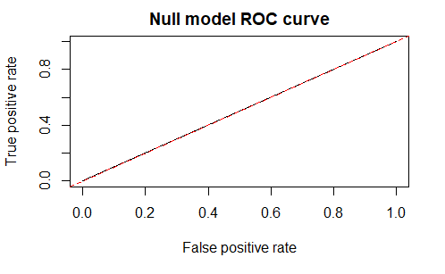

```r
plot(performance(prediction(dTest$predNull, dTest$High_ATAR), "tpr", "fpr"),
     main = "Null model ROC curve") %>% abline(a = 0, b = 1, col = "red", lty = 2)
```

The red dashed lines represents a line of no-discrimination or random guesses. The ROC curve which perform no better than random guesses would return the same pattern as this dashed line. If we calculate the area under this ROC curve, it would return $0.5$. Thus, we can use the AUC of $0.5$ as our lower-bound AUC for model evaluation.

### 2.1.2 Single-variable Models

Now, the single-variable models are built to help organize the training data into a number of subsets indexed by the predictive variable and then store a summary of the distribution of outcome as their future prediction. The best single-variable model is also useful to compare any complicated model against. If the complicated model does not outperform the best single-variable model, then that model cannot be justified.

1. Identifying outcome and creating variable object (vars)

In this project, we want to predict the enrollment whether the average ATAR is high (above 80) or not. Hence, the object *outcome* and *pos* were assigned with the value representing our outcome of interest. A **High_ATAR** column was created in the Cleaning Data section having ATAR above 80 classified as ‘1’ and others classified as ‘-1’. The variable object, *vars*, consists of name of attributes excluding the outcome column, columns associated with the outcome and uniformly distributed random numbers column.

```r
outcome <- "High_ATAR"
pos <- "1"
vars <- setdiff(colnames(dTrainAll), c(outcome, "rgroup", "atar_fixed", "ATAR_Group"))
```

2. Identifying categorical variables and numerical variables in the data frame and further splitting training data into training and calibration set.

Since categorical and numerical variables required different techniques to deal with, extracting the name of all the variables and put them in different objects based on their class for later analysis is useful. Also, the training set of data was divided further into the calibration set for features selection.

```r
catVars <- vars[sapply(dTrainAll[, vars], class) %in% c('factor', 'character')]
numericVars <- vars[sapply(dTrainAll[, vars], class) %in% c('numeric', 'integer')]

useForCal <- rbinom(n = dim(dTrainAll)[[1]], size = 1, prob = 0.1) > 0
dCal <- subset(dTrainAll, useForCal)
dTrain <- subset(dTrainAll, !useForCal)
```

3. Building single-variable models for all categorical variables

A single-variable model is useful in selecting potential classifiers. It is essentially a model building method using one variable at a time, which is pretty exasperating for dataset with many variables. Hence, with the use of `function()` and for loop, we are able to build a single-categorical variable models to all variables in our dataset using the code chunk below.

- Function to repeat model building

```r
mkPredC <- function(outCol, varCol, appCol) {
  pPos <- sum(outCol == pos)/length(outCol)
  naTab <- table(as.factor(outCol[is.na(varCol)]))
  pPosWna <- (naTab/sum(naTab))[pos]
  vTab <- table(as.factor(outCol), varCol)
  pPosWv <- (vTab[pos,] + 1.0e-3 * pPos)/(colSums(vTab) + 1.0e-3)
  pred <- pPosWv[appCol]
  pred[is.na(appCol)] <- pPosWna
  pred[is.na(pred)] <- pPos
  pred
}
```

- Applying single-categorical variable models to all of our datasets

```r
for(v in catVars) {
  pi <- paste('pred', v, sep = '')
  dTrain[, pi] <- mkPredC(dTrain[, outcome], dTrain[, v], dTrain[, v])
  dCal[, pi] <- mkPredC(dTrain[, outcome], dTrain[, v], dCal[, v])
  dTest[, pi] <- mkPredC(dTrain[, outcome], dTrain[, v], dTest[, v])
}
```

An area under the receiver operating characteristic curve (AUC of ROC curve) was computed to assess classifiers performance and identify over-fitting problem. The closer to 1 the AUC is, the better the classifier. Since the National Enrollment data consists of many variables, with the use of `function()` and for loop, we can work out the area under the ROC curve for each variables for both training set and calibration set.

```r
calcAUC <- function(predcol, outcol) {
  perf <- performance(prediction(predcol, outcol == pos), 'auc')
  as.numeric(perf@y.values)
}

for(v in catVars) {
  pi <- paste('pred', v, sep='')
  aucTrain <- calcAUC(dTrain[, pi], dTrain[, outcome])
  if(aucTrain >= 0.8) {
    aucCal <- calcAUC(dCal[, pi], dCal[, outcome])
    print(sprintf("%s, trainAUC: %4.3f calibrationAUC: %4.3f", pi, aucTrain, aucCal))
  }
}
```

```
[1] "predage, trainAUC: 0.840 calibrationAUC: 0.849"
[1] "predbasis_for_admission, trainAUC: 0.885 calibrationAUC: 0.902"
[1] "predhighest_ed_attainment, trainAUC: 0.895 calibrationAUC: 0.903"
```

Using the training AUC threshold of $0.8$, only the classifiers in training set with AUC greater than or equal to 0.8 were printed. The AUC is essentially the probability that a classifier will rank a randomly chosen positive instance higher than a randomly chosen negative one (“Receiver operating_characteristic”, n.d.). From above output, the classifiers identify by the code satisfied by the threshold are **predage**, **predbasis_for_admission** and **predhighest_ed_attainment**, while **predhighest_ed_attainment** seems to have the highest AUCs. Also, the training AUC of these classifiers are approximately close to their calibration AUCs, which indicates that the variables are not subject to over-fitting.

Below is the ROC curve illustrating relative trade-offs between true positive and false positive rates of *predage*, *predbasis_for_admission* and *predhighest_ed_attainment*, respectively. The red dashed lines represents a line of no-discrimination or random guess. An ROC curve above the no-discrimination line indicates better prediction than random guessing. The closer the curve to the top left corner of the plot, the better the prediction.

```r
par(mfrow = c(1,3))
plot(performance(prediction(dTest[, "predage"], dTest[, outcome]), "tpr", "fpr"),
     main = "Age") %>% abline(a = 0, b = 1, col = "red", lty = 2)
plot(performance(prediction(dTest[, "predbasis_for_admission"], dTest[, outcome]), "tpr", "fpr"),
     main = "Basis for Admission") %>% abline(a = 0, b = 1, col = "red", lty = 2)
```

[figure not shown]

```r
plot(performance(prediction(dTest[, "predhighest_ed_attainment"], dTest[, outcome]), "tpr", "fpr"),
     main = "Highest Education Attainment") %>% abline(a = 0, b = 1, col = "red", lty = 2)
```

As expected, all the ROC curves shows a relatively high true positive rate with respect to the false positive rate. The ROC curve of the single-variable model using **highest_ed_attainment** seems to be the one that is closest the top left corner of the plot. Hence, we can conclude that our best single-variable model to predict enrollment with high ATAR is **predhighest_ed_attainment** with AUC of 0.89.

4. Converting numeric variables into categorical

This can be done by binning numeric variable into a number of ranges. There is only one numeric variable in our data set which is **atar_fixed**. However, since our outcome variable **High_ATAR** is essentially derived from the atar_fixed column, then it was dropped from our investigation from the very beginning due to redundancy problem. Hence, we do not have to deal with numeric variable in this case.

5. 100-fold Cross-validation

Recall the AUC of classifiers in both training and calibration set we obtained from step 5, training AUC is fairly close to calibration AUC which means that our training estimate tends to be good and not over-fit. To ensure that we were not over-fitting the model, repeated cross-validation was conducted on the single-variable model based on variable *Highest_ed_attainment*.

```r
fCross <- function() {
  useForCalRep <- rbinom(n = dim(dTrainAll)[[1]], size = 1,prob = 0.1) > 0
  predRep <- mkPredC(dTrainAll[!useForCalRep, outcome],
                     dTrainAll[!useForCalRep, var],
                     dTrainAll[useForCalRep, var])
  calcAUC(predRep, dTrainAll[useForCalRep, outcome])
}

var <- "highest_ed_attainment"

aucs <- replicate(100, fCross())

print(sprintf("%s, MeanAUC: %4.3f sdAUC: %4.3f", var, mean(aucs), sd(aucs)))
```

```
[1] "highest_ed_attainment, MeanAUC: 0.896 sdAUC: 0.004"
```

The original training AUC of **highest_ed_attainment** variable of $0.895$ is very close to the 100-fold replicated estimate of mean AUC of $0.896$ with a relatively small standard error of $0.004$. Hence, our original estimated AUC is good enough.

In conclusion, the most promising variable is **highest_ed_attainment**, which has training AUC of 0.895 and calibration AUC of 0.903. Hence, it is apparently much better than random guesses or our null model. In the following sections, we will compare the best single-variable model’s AUCs with other complicated models to decide whether which model is the best.

### 2.1.3 The Bayes Rate Model

The Bayes rate or error rate of a saturated model essentially tells us what high performance looks like. It is an ideal model with no bias or variance terms and can be described as the limit on prediction accuracy due to unexplained variance. Unfortunately, determining the exact Bayes rate is not always feasible, because if we are able to find it, our job would already be done. The Bayes rate model, however, can be estimated by building a look-up table for all possible variable combination or using a nearest-neighbour classifier. However, the only problem arise for the Bayes rate model using a look-up table is when there are multiple examples with the exact same set of known facts but different outcome. For example, there are five female domestic students who studied data sciences at UWA in 2017. Assuming that all other characteristics are the same, only one of them obtained a substantially high ATAR. Let’s put this example into a table for a better understanding.

```r
t <- as.table(matrix(data = c("female", "female", "female", "female", "female",
                              TRUE, TRUE, TRUE, TRUE, TRUE,
                              "DataSci", "DataSci", "DataSci", "DataSci", "DataSci",
                              "UWA", "UWA", "UWA", "UWA", "UWA",
                              "2017", "2017", "2017", "2017", "2017",
                              FALSE, FALSE, FALSE, TRUE, FALSE,
                              FALSE, FALSE, FALSE, FALSE, FALSE),
                     nrow = 5, ncol = 7))
rownames(t) <- c(1:5)
colnames(t) <- c("gender", "domestic", "course", "uni", "year", "high ATAR", "Bayes")
print(t)
```

```
  gender domestic course  uni year high ATAR Bayes
1 female TRUE     DataSci UWA 2017 FALSE     FALSE
2 female TRUE     DataSci UWA 2017 FALSE     FALSE
3 female TRUE     DataSci UWA 2017 FALSE     FALSE
4 female TRUE     DataSci UWA 2017 TRUE      FALSE
5 female TRUE     DataSci UWA 2017 FALSE     FALSE
```

Now, we can see that there’s a disagreement in the high ATAR outcomes where all other features are the same. The Bayes rate model, in this example, will undoubtedly predict that the student number 4 did not obtain a high ATAR due to the fact that all other students with the same characteristics did not. From here, we can conclude that the highest performance we can get for this example is an accuracy of $4/5 = 80$ percent.

```r
rm(t)
```

For our dataset, it is actually very difficult to do the same thing, since there are many feature values and each feature also has a large number of levels. Hence, it probably be more appropriate to use the nearest-neighbour classifier as an estimation of the Bayes rate. We will discuss about the nearest neighbour algorithm in section 2.4 K-nearest Neighbour Method.

## 2.2 Naive Bayes

Once, we are done building single-variable models, then we can move on to building models using many variable. First, Naive Bayes is a memorization method which is useful for data with many categorical input variables with a very large number of possible values. The method is known to be a good first attempt at solving product categorical problem. Hence, it can be used to identify whether the enrollment is with high ATAR (above 80) or not. In this section, `naiveBayes()` function from `e1071` packages was applied to determine the conditional posterior probability of a categorical class variable given independent predictor variables using the famous Bayes rule. Then, the obtained Naive Bayes model (nbmodel) was applied to make a prediction using `prediction()` function. Lastly, the AUCs of training set, test set and calibration set were then calculated to evaluate the Naive Bayes model performance.

```r
ff <- paste('as.factor(', outcome, '>0) ~ ',
            paste(catVars, collapse = ' + '), sep = '')
nbmodel <- naiveBayes(as.formula(ff), data = dCal)
dTrain$nbpred <- predict(nbmodel, newdata = dTrain, type= 'raw')[, 'TRUE']
dCal$nbpred <- predict(nbmodel, newdata = dCal, type='raw')[, 'TRUE']
dTest$nbpred <- predict(nbmodel,newdata = dTest, type='raw')[, 'TRUE']

calcAUC(dTrain$nbpred, dTrain[, outcome])
```

```
[1] 0.9402017
```

```r
calcAUC(dCal$nbpred, dCal[, outcome])
```

```
[1] 0.9500899
```

```r
calcAUC(dTest$nbpred, dTest[, outcome])
```

```
[1] 0.9432486
```

The area under the ROC curves (AUCs) in this case is a measure of prediction quality or performance of the model. The AUCs above our lower bound of 0.5 means that the model predictive performance is better than random guesses, while the AUCs of 1.0 means the perfect classifiers. The Naive Bayes model returns all the AUCS of about 0.94 which are very close to 1 and close to each other. Recall that our best single-variable model returns the AUC of 0.89. This suggests that Naive Bayes model performs better than the single-variable model and is a very good classifier without over-fitting problem presented. Below are the corresponding ROC curves of the AUCs we calculated above.

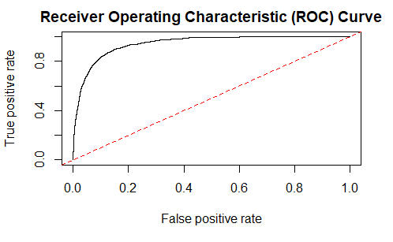

```r
plot(performance(prediction(dTest$nbpred, dTest[, outcome]), "tpr", "fpr"),
     main = "Receiver Operating Characteristic (ROC) Curve") %>% abline(a = 0, b = 1, col = "red", lty = 2)
```

## 2.3 Decision Trees using Selected Features

Decision tree is a classification method which is useful when there’s an ‘if-then’ relationship between input variables and the outcome, and when the input variables have an ‘AND’ relationship between each other. The process involves splitting the training data into pieces (data cuts) and apply a simple memorized constant on each piece. The best data cuts based on many criteria are then chosen to fit a decision tree model.

Firstly, a variable selection based on Akaike Information Criterion (AIC) is conducted. This preselecting process is done to help control a possible source of noise and over-fitting. We can do that by using a knowledge of log likelihood, deviance and Akaike Information Criterion. The AIC is particularly useful for comparing models with different measures of complexity and variable with different number of levels. As mentioned before, we will use calibration set for variables selecting.

```r
logLikelyhood <- function(outCol, predCol) {
  sum(ifelse(outCol == pos, log(predCol), log(1 - predCol)))
}

selVars <- c()
minStep <- 5
baseRateCheck <- logLikelyhood(dCal[, outcome],
                               sum(dCal[, outcome] == pos)/length(dCal[, outcome]))
for(v in catVars) {
  pi <- paste('pred', v, sep = '')
  liCheck <- 2*((logLikelyhood(dCal[, outcome], dCal[, pi]) - baseRateCheck))

  if(liCheck > minStep) {
    print(sprintf("%s, calibrationScore: %g", pi, liCheck))
    selVars <- c(selVars, pi)
  }
}
```

```
[1] "predYear, calibrationScore: 196.239"
[1] "predstate, calibrationScore: 47.1361"
[1] "predInstitution, calibrationScore: 452.275"
[1] "predInstitution_Type, calibrationScore: 244.821"
[1] "predbroad_course_type, calibrationScore: 542.667"
[1] "predcourse_type, calibrationScore: 646.862"
[1] "predage, calibrationScore: 1533.18"
[1] "predCommencing, calibrationScore: 277.218"
[1] "predoverseas, calibrationScore: 193.343"
[1] "predattendance_type, calibrationScore: 377.876"
[1] "predattendance_mode, calibrationScore: 195.074"
[1] "predbroad_foe, calibrationScore: 146.821"
[1] "predNarrow_FOE, calibrationScore: 323.552"
[1] "predbasis_for_admission, calibrationScore: 2329.95"
[1] "predspecial_course, calibrationScore: 31.9094"
[1] "predcountry_of_birth, calibrationScore: 23.5"
[1] "predhighest_ed_attainment, calibrationScore: 2273.34"
[1] "predonshore_indicator, calibrationScore: 28.4002"
[1] "predRegional, calibrationScore: 53.4676"
[1] "predRegion, calibrationScore: 212.057"
[1] "predperm_home_state, calibrationScore: 202.777"
[1] "predAustralian_Region_fixed, calibrationScore: 184.371"
[1] "predsuppbfoe_fixed, calibrationScore: 122.733"
[1] "prednesb_fixed, calibrationScore: 57.0949"
[1] "predcampus_country_fixed, calibrationScore: 91.017"
[1] "predperm_home_country_fixed, calibrationScore: 193.868"
```

There are 26 variables out of 33 variables which were preselected based on the AIC score as shown in the above list. Next, with the use of `rpart()` function from rpart package, we are able to build a decision tree model of High ATAR variable below.

```r
f <- paste(outcome, '>0 ~ ', paste(selVars, collapse = ' + '), sep = '')
tmodel <- rpart(f, data = dTrain,
                control = rpart.control(cp = 0.001,
                                        minsplit = 1000,
                                        minbucket = 1000,
                                        maxdepth = 3))
print(tmodel)
```

```
n= 97566

node), split, n, deviance, yval
      * denotes terminal node

 1) root 97566 7766.0810 0.087202510
   2) predbasis_for_admission< 0.2299717 80992 1791.5160 0.022631860
     4) predhighest_ed_attainment< 0.101658 71129  666.6323 0.009461682 *
     5) predhighest_ed_attainment>=0.101658 9863 1023.5710 0.117611300
      10) predInstitution< 0.1469653 8780  712.3503 0.089066060 *
      11) predInstitution>=0.1469653 1083  246.0665 0.349030500 *
   3) predbasis_for_admission>=0.2299717 16574 3986.7160 0.402739200
     6) predInstitution< 0.1075778 9271 1743.9240 0.251213500
      12) predInstitution< 0.03561061 2748  263.3315 0.107350800 *
      13) predInstitution>=0.03561061 6523 1399.7590 0.311819700 *
     7) predInstitution>=0.1075778 7303 1759.7050 0.595097900
      14) predhighest_ed_attainment< 0.2491357 1582  289.7598 0.241466500 *
      15) predhighest_ed_attainment>=0.2491357 5721 1217.4000 0.692885900 *
```

The decision tree has 13 nodes, while the node 1 is the root note without parent. The indentation demonstrates how deep each tree node is with* indicating the terminal or leaf node. The condition on each parent node must be met to move to the corresponding child node. The three numbers after the condition of each node are the number of training items that navigated to the node, the deviance measuring how much uncertainty remains at a given node, and the fraction of items that were in the positive class at the node, respectively. This decision tree plot illustrating these output is shown below using the function `fancyRpartPlot`.

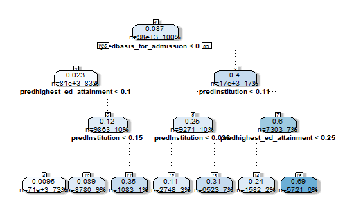

```r
fancyRpartPlot(tmodel, caption = NULL, palettes = "Blues")
```

The top number inside the box represents the fraction of items that were in the positive class (High ATAR) having the dark blue colour indicates the highest proportion (fraction) of the positive class and the light blue colour indicates the opposite. The number of training items in each node (n) and the percentage of the training data that has been split with respect to its parent node are also given inside the box. The condition of each parent node is also noted at the bottom of the box. From our decision tree model, it is found that node 15 with predbasis_for_admission > 0.23, predInstitution > 0.11 and predhighest_ed_attainment > 0.25 holds the highest fraction of High ATAR of 0.69.

Again, to check the model predicting performance, the AUC of training set, test set and calibration set when we pass the prediction function to the tmodel are determined as follows:

```r
print(calcAUC(predict(tmodel, newdata=dTrain), dTrain[, outcome]))
```

```
[1] 0.9113762
```

```r
print(calcAUC(predict(tmodel, newdata=dTest), dTest[, outcome]))
```

```
[1] 0.9127934
```

```r
print(calcAUC(predict(tmodel, newdata=dCal), dCal[, outcome]))
```

```
[1] 0.9184804
```

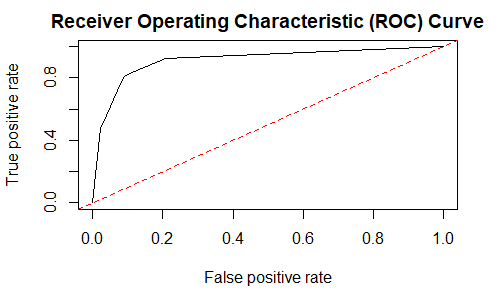

```r
plot(performance(prediction(predict(tmodel, newdata=dTest), dTest[, outcome]), "tpr", "fpr"),
     main = "Receiver Operating Characteristic (ROC) Curve") %>% abline(a = 0, b = 1, col = "red", lty = 2)
```

All the AUCs are above 0.5 and 0.89 and essentially close to 1 which indicates that the decision tree model performs better than the null model and the single-variable model. However, the decision tree’s AUC is a bit less than that of Naive Bayes. So, this suggests that the Naive Bayes model perform better.

## 2.4 K-nearest Neighbour Method

The K-nearest neighbour classification method is one of the most convenient classification method to carry out in R. It is essentially the method that scores an example by finding the $k$ training examples nearest to the example and then taking the average outcomes as the score. Then, the question is how many $k$ we would want to build a sensible model? Since the probability of high ATAR is considerably low (about 8.7%), choosing a low number of $k$ for kNN will underestimate all the useful range of probabilities. Hence, for the rare event like this, a large $k$ value is usually employed. The basic rule of thumb is that we would want to see 10 positive example in each of the neighbourhood. So, we would want $k$ around $10/0.087 \approx 115$ or greater. In this section, the 200 nearest (in Euclidean distance) training set vectors are found, and the classification is decided by majority vote with ties broken at random.

As we discussed in section 2.1.3 The Bayes Rate Model, the nearest-neighbour classifier is also a good estimator of Bayes rate for the National Enrollment dataset.

kNN method is conducted using `knn()` function from package `class`. Again, the area under the ROC curve are calculated

```r
nK <- 200
knnTrain <- dCal[, selVars]
knnCl <- dCal[, outcome] == pos
knnPred <- function(df) {
    knnDecision <- knn(knnTrain, df, knnCl, k = nK, prob = T)
    ifelse(knnDecision == TRUE, attributes(knnDecision)$prob, 1-(attributes(knnDecision)$prob))
}

print(calcAUC(knnPred(dTrain[, selVars]), dTrain[, outcome]))
```

```
[1] 0.9423186
```

```r
print(calcAUC(knnPred(dCal[, selVars]) ,dCal[, outcome]))
```

```
[1] 0.9532982
```

```r
print(calcAUC(knnPred(dTest[, selVars]), dTest[, outcome]))
```

```
[1] 0.9450924
```

All the AUCs are very close to one which indicates a good separation performance of a model. Also, the AUCs of kNN model are all higher than the null model, the single variable model, the decision tree model, and the Naive Bayes Model. Hence, we can conclude that the classification model based on K-nearest neighbour method is essentially the best model to predict the enrollments with high ATAR, and thus our best Bayes rate estimate.

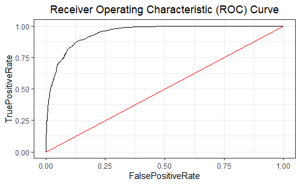

```r
plotROC <- function(predcol,outcol) {
   perf <- performance(prediction(predcol, outcol == pos), "tpr", "fpr")
   pf <- data.frame(FalsePositiveRate = perf@x.values[[1]],
                    TruePositiveRate = perf@y.values[[1]])
ggplot() +
  geom_line(data = pf, aes(x = FalsePositiveRate, y = TruePositiveRate)) +
  geom_line(aes(x = c(0,1), y = c(0,1)), colour = "red") +
  theme_bw() +
  labs(title = "Receiver Operating Characteristic (ROC) Curve") +
  theme(plot.title = element_text(hjust = .5))
}
print(plotROC(knnPred(dTest[, selVars]), dTest[, outcome]))
```

The trade-off between the sensitivity (TPR) and specificity (FPR) as shown by the ROC curve above suggests a relatively high TPR with respect to FPR, which is a good sign. The ROC curve above the red diagonal line also indicates a better performance than random guesses.

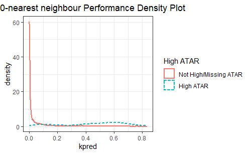

```r
dCal$kpred <- knnPred(dCal[, selVars])

ggplot(dCal) +
  geom_density(aes(x = kpred, colour = as.factor(High_ATAR),
                   linetype = as.factor(High_ATAR)), size = 1) +
  theme_bw() +
  labs(title = "200-nearest neighbour Performance Density Plot") +
  scale_colour_discrete(name = "High ATAR",
                        breaks = c("-1", "1"),
                        labels = c("Not High/Missing ATAR", "High ATAR")) +
  scale_linetype_discrete(name = "High ATAR",
                        breaks = c("-1", "1"),
                        labels = c("Not High/Missing ATAR", "High ATAR")) +
  theme(plot.title = element_text(hjust = .5))
```

The above double density plot shows the conditional distribution of of kNN model prediction (kpred) for High ATAR enrollments (the blue dashed-line density plot) and the distribution of kpred for non-high ATAR enrollments (the red solid-line density plot. A fairly clear separation between the double density plot is expected for a good kNN model. The double density plot above suggests that a relatively low value of kpred are rather common for non-high ATAR enrollments and very rare for high ATAR enrollments. Hence, we can conclude that a low value of kpred is a good evidence that the enrollments is with non-high or missing ATAR.

# 3 Clustering

Clustering is an unsupervised methods which is used to discover unknown relationships in the data. Unlike the supervised or memorization methods in the previous section, there is no obvious outcome we try to predict; instead we are trying to uncover some obscure patterns we had not previously suspected. There are two clustering approaches mentioned in the text book, Hierarchical clustering and k-means clustering algorithms. In the hierarchical clustering method, clusters have a standard parent-child relationship or a tree-based structure where similar clusters are combined together and continue to combine until all objects are in the same cluster, whereas K-means clustering approach tries to group similar observations in the same cluster. K-means clustering is also known to be effective for finding clusters in quantitative data.

The expectation of this project is to group the enrollments into clusters such that every enrollment in the same cluster is more similar to one another than it is to to enrollments in other clusters. Hence, we are able to find groups of students with similar enrollment patterns.

The code in the following section was adapted from Chapter 8 of Practical Data Science with R (Zumel and Mount, 2014).

## 3.1 Data Preparation

Firstly, we will choose or compute a set of feature variables to apply the clustering algorithm. In this section, we obtained the numerical aggregations for each institution type each broad field of study each enrollment year, the average age, the proportion of high ATAR students, the proportion of male students, the number of international students, the number of home-state students and the number of inter-state students. Since, there’s a substantially high proportion of enrollments with missing ATAR due to the students did not commence an undergraduate course, did not complete Australian Year 12, or their ATAR score is just simply not available, I decided to limit the investigation only for undergraduate students with ATAR, so that we can average the ATAR score without bias.

- Data Preparation

```r
# Converting age range to numeric (assume age distribution is left skewed)
enrol2$age_num <- ifelse(enrol2$age == "16 and under", 16, # Assume mode is 16
                  ifelse(enrol2$age == "30 to 39", mean(30:39),
                  ifelse(enrol2$age == "40 to 49", mean(40:49),
                  ifelse(enrol2$age == "50 to 59", mean(50:59),
                  ifelse(enrol2$age == "60 and over", 60, # Assume mode is 60
                         as.character(enrol2$age))))))
enrol2$age_num <- as.numeric(enrol2$age_num)

# International students
enrol2$International <- ifelse(enrol2$Australian_Region_fixed == "International", 1, 0)

# home-state students
enrol2$HomeState <- ifelse(enrol2$Australian_Region_fixed == "HomeState", 1, 0)

# inter-state students
enrol2$InterState <- ifelse(enrol2$Australian_Region_fixed == "InterState", 1, 0)

# Male students
enrol2$Male <- ifelse(enrol2$gender == "Males", 1, 0)
```

- Numerical aggregations

With the use of data transformation package `dplyr` and its data handling function (pipe), we are able to obtain the numerical aggregation of the average age, the average ATAR score, proportion of male students, number of international enrollments, number of homestate enrollments and the number of interstate enrollments grouped by enrollment year, institution type and broad field of education type.

```r
enrol3 <- enrol2 %>%
  subset(!is.na(atar_fixed)) %>%
  group_by(Year, Institution_Type, broad_foe) %>%
  summarise(avgAge = mean(age_num, na.rm = TRUE),
            avgATAR = mean(atar_fixed, na.rm = TRUE),
            propMale = mean(Male),
            noInter = sum(International),
            noHomeState = sum(HomeState),
            noInterState = sum(InterState)) %>%
  transform(Year = as.character(Year),
            Institution_Type = as.character(Institution_Type),
            broad_foe = as.character(broad_foe)) %>%
  unite(Yr_InsType_Foe, Year, Institution_Type, broad_foe,
        sep = " ", remove = TRUE) %>%
  transform(Yr_InsType_Foe = as.factor(Yr_InsType_Foe))
head(enrol3)
```

|  | Yr_InsType_Foe | avgAge | avgATAR | propMale | noInter | noHomeState | noInterState |
| --- | --- | --- | --- | --- | --- | --- | --- |
| 1 | 2005 College Engineering And Relate | 17.00000 | 93.00000 | 1.0000000 | 0 | 1 | 0 |
| 2 | 2005 College Society And Culture | 18.00000 | 74.00000 | 0.0000000 | 0 | 0 | 1 |
| 3 | 2005 Go8 University Agriculture, Environme | 19.00000 | 68.37500 | 0.5000000 | 1 | 0 | 7 |
| 4 | 2005 Go8 University Architecture And Build | 18.22222 | 87.22222 | 0.4444444 | 0 | 0 | 9 |
| 5 | 2005 Go8 University Creative Arts | 18.12500 | 86.93750 | 0.3125000 | 0 | 1 | 15 |
| 6 | 2005 Go8 University Education | 18.83333 | 79.50000 | 0.6666667 | 0 | 1 | 5 |

- Standardized data

To avoid clustering with inconsistent units and to take into account the degree of difference in each attributes, a data transformation process is required before carry out the analysis. In order to make the clustering more coordinate-free, we usually standardize all the columns to have a mean value of 0 and a standard deviation of 1 (z-normalization). Once the data is scaled, now the variables can be comparable without bias. This can be done by passing the function `scale` to the numeric attributes, namely avgAge, avgATAR, propMale, noInter, noHomeState and noInterState.

```r
vars.to.use <- colnames(enrol3)[-1]
pmatrix <- scale(enrol3[, vars.to.use])
pcenter <- attr(pmatrix, "scaled:center")
pscale <- attr(pmatrix, "scaled:scale")
```

- Measuring distance

In order to group observations into clusters, we need to find similarity and dissimilarity between data points. This can be done by measuring distance between each points, where points in a cluster are closer to each other than they are to the points in other clusters. There are essentially four most commons approaches to determine distance and dissimilarity, namely Euclidean distance, Hamming distance, Manhattan distance and Cosine similarity. Since, our new dataset **enrol3** consists of numeric (quantitative) values, the Euclidean distance between data points were used to determine similarity and dissimilarity of the observations. Below, the function `dist` is applied to our scaled data to calculate the distance matrix using the Euclidean distance method.

```r
d <- dist(pmatrix, method = "euclidean")
```

## 3.2 Hierarchical Clustering

By passing the function `hclust` to the distance matrix using Ward’s method, we are able to plot a cluster dendogram. The Ward’s method basically refers to an iterative merge of individual data point into clusters so as to minimize the total within sum of squares (WSS) of the clustering. The dendogram is essentially a tree representing the nested clusters as shown below.

```r
pfit <- hclust(d, method = "ward.D")
plot(pfit, labels = FALSE)
rect.hclust(pfit, k = 2, border = 3:4)
```

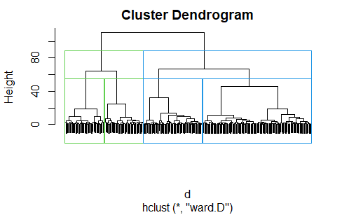

```r
rect.hclust(pfit, k = 4, border = c(3,3,4,4))
```

The cluster dendogram above suggests that there should be around 2 or 4 clusters. Here, the function `rect.hclust` was used to draw rectangles around the branch of a dendrogram highlighting the corresponding clusters for $k = 2$ and $k = 4$. Intuitively, I would choose $k = 2$ because it is possible that the clusters correspond to Go8 and non-Go8 university. We can investigate clustering with different number of clusters by using a function `cutree` to extract the members of each cluster from the hclust object, and then we plot the clusters by projecting them on the first two principal component.

- $k = 2$

```r
groupsk2 <- cutree(pfit, k = 2)
print_clusters <- function(labels, k) {
  for(i in 1:k) {
    print(paste("cluster", i))
    print(enrol3[labels == i,
                  c("Yr_InsType_Foe", "avgAge",
                    "avgATAR", "propMale","noInter",
                    "noHomeState", "noInterState")])
  }
}
print_clusters(groupsk2, 2)
```

```
[1] "cluster 1"
```

|  | Yr_InsType_Foe | avgAge | avgATAR | propMale | noInter | noHomeState | noInterState |
| --- | --- | --- | --- | --- | --- | --- | --- |
| 1 | 2005 College Engineering And Relate | 17.00000 | 93.00000 | 1.00000000 | 0 | 1 | 0 |
| 2 | 2005 College Society And Culture | 18.00000 | 74.00000 | 0.00000000 | 0 | 0 | 1 |
| 3 | 2005 Go8 University Agriculture, Environme | 19.00000 | 68.37500 | 0.50000000 | 1 | 0 | 7 |
| 4 | 2005 Go8 University Architecture And Build | 18.22222 | 87.22222 | 0.44444444 | 0 | 0 | 9 |
| 5 | 2005 Go8 University Creative Arts | 18.12500 | 86.93750 | 0.31250000 | 0 | 1 | 15 |
| 6 | 2005 Go8 University Education | 18.83333 | 79.50000 | 0.66666667 | 0 | 1 | 5 |
| 7 | 2005 Go8 University Engineering And Relate | 17.61538 | 91.50000 | 0.84615385 | 1 | 4 | 21 |
| 8 | 2005 Go8 University Health | 18.28571 | 95.07143 | 0.28571429 | 0 | 3 | 11 |
| 9 | 2005 Go8 University Information Technology | 18.60000 | 88.80000 | 0.60000000 | 0 | 1 | 4 |
| 11 | 2005 Go8 University Natural And Physical S | 19.00000 | 88.41860 | 0.53488372 | 1 | 5 | 37 |

[output cut: 175 more lines]

```
[1] "cluster 2"
```

|  | Yr_InsType_Foe | avgAge | avgATAR | propMale | noInter | noHomeState | noInterState |
| --- | --- | --- | --- | --- | --- | --- | --- |
| 10 | 2005 Go8 University Management And Commerc | 18.02564 | 88.61538 | 0.5128205 | 2 | 7 | 30 |
| 18 | 2005 Non-Go8 University Health | 18.90090 | 79.91892 | 0.1711712 | 1 | 12 | 98 |
| 20 | 2005 Non-Go8 University Management And Commerc | 18.90435 | 76.43478 | 0.4347826 | 6 | 7 | 102 |
| 22 | 2005 Non-Go8 University Society And Culture | 19.40217 | 75.02174 | 0.3115942 | 3 | 9 | 126 |
| 34 | 2006 Go8 University Management And Commerc | 18.60241 | 89.81928 | 0.5301205 | 8 | 5 | 70 |
| 35 | 2006 Go8 University Natural And Physical S | 18.28788 | 88.50000 | 0.3787879 | 3 | 7 | 56 |
| 36 | 2006 Go8 University Society And Culture | 19.05200 | 87.03200 | 0.3440000 | 3 | 2 | 120 |
| 40 | 2006 Non-Go8 University Education | 20.71849 | 76.61345 | 0.2184874 | 0 | 10 | 109 |
| 42 | 2006 Non-Go8 University Health | 19.61515 | 77.22424 | 0.2000000 | 1 | 5 | 159 |
| 44 | 2006 Non-Go8 University Management And Commerc | 19.89140 | 76.78281 | 0.5294118 | 2 | 12 | 207 |

[output cut: 77 more lines]

- $k = 4$

```r
groupsk4 <- cutree(pfit, k = 4)
print_clusters(groupsk4, 4)
```

```
[1] "cluster 1"
```

|  | Yr_InsType_Foe | avgAge | avgATAR | propMale | noInter | noHomeState | noInterState |
| --- | --- | --- | --- | --- | --- | --- | --- |
| 1 | 2005 College Engineering And Relate | 17.00000 | 93.00000 | 1.0000000 | 0 | 1 | 0 |
| 6 | 2005 Go8 University Education | 18.83333 | 79.50000 | 0.6666667 | 0 | 1 | 5 |
| 7 | 2005 Go8 University Engineering And Relate | 17.61538 | 91.50000 | 0.8461538 | 1 | 4 | 21 |
| 14 | 2005 Non-Go8 University Architecture And Build | 17.72727 | 87.00000 | 0.7272727 | 0 | 1 | 10 |
| 17 | 2005 Non-Go8 University Engineering And Relate | 19.07778 | 78.06667 | 0.7555556 | 2 | 6 | 37 |
| 19 | 2005 Non-Go8 University Information Technology | 18.13043 | 70.39130 | 0.8260870 | 0 | 2 | 21 |
| 23 | 2006 College Agriculture, Environme | 19.00000 | 40.00000 | 1.0000000 | 0 | 0 | 1 |
| 24 | 2006 College Engineering And Relate | 20.00000 | 91.00000 | 1.0000000 | 0 | 0 | 2 |
| 25 | 2006 College Natural And Physical S | 18.00000 | 79.50000 | 1.0000000 | 0 | 0 | 2 |
| 26 | 2006 College Society And Culture | 18.50000 | 87.50000 | 1.0000000 | 0 | 0 | 2 |

[output cut: 55 more lines]

```
[1] "cluster 2"
```

|  | Yr_InsType_Foe | avgAge | avgATAR | propMale | noInter | noHomeState | noInterState |
| --- | --- | --- | --- | --- | --- | --- | --- |
| 2 | 2005 College Society And Culture | 18.00000 | 74.00000 | 0.00000000 | 0 | 0 | 1 |
| 3 | 2005 Go8 University Agriculture, Environme | 19.00000 | 68.37500 | 0.50000000 | 1 | 0 | 7 |
| 4 | 2005 Go8 University Architecture And Build | 18.22222 | 87.22222 | 0.44444444 | 0 | 0 | 9 |
| 5 | 2005 Go8 University Creative Arts | 18.12500 | 86.93750 | 0.31250000 | 0 | 1 | 15 |
| 8 | 2005 Go8 University Health | 18.28571 | 95.07143 | 0.28571429 | 0 | 3 | 11 |
| 9 | 2005 Go8 University Information Technology | 18.60000 | 88.80000 | 0.60000000 | 0 | 1 | 4 |
| 11 | 2005 Go8 University Natural And Physical S | 19.00000 | 88.41860 | 0.53488372 | 1 | 5 | 37 |
| 12 | 2005 Go8 University Society And Culture | 18.61594 | 88.28986 | 0.34782609 | 0 | 2 | 67 |
| 13 | 2005 Non-Go8 University Agriculture, Environme | 19.25000 | 80.25000 | 0.25000000 | 0 | 0 | 8 |
| 15 | 2005 Non-Go8 University Creative Arts | 19.00833 | 77.61667 | 0.35000000 | 1 | 2 | 57 |

[output cut: 110 more lines]

```
[1] "cluster 3"
```

|  | Yr_InsType_Foe | avgAge | avgATAR | propMale | noInter | noHomeState | noInterState |
| --- | --- | --- | --- | --- | --- | --- | --- |
| 10 | 2005 Go8 University Management And Commerc | 18.02564 | 88.61538 | 0.5128205 | 2 | 7 | 30 |
| 20 | 2005 Non-Go8 University Management And Commerc | 18.90435 | 76.43478 | 0.4347826 | 6 | 7 | 102 |
| 34 | 2006 Go8 University Management And Commerc | 18.60241 | 89.81928 | 0.5301205 | 8 | 5 | 70 |
| 35 | 2006 Go8 University Natural And Physical S | 18.28788 | 88.50000 | 0.3787879 | 3 | 7 | 56 |
| 36 | 2006 Go8 University Society And Culture | 19.05200 | 87.03200 | 0.3440000 | 3 | 2 | 120 |
| 53 | 2007 Go8 University Engineering And Relate | 18.92614 | 90.30682 | 0.7727273 | 0 | 9 | 79 |
| 54 | 2007 Go8 University Health | 19.06875 | 90.88750 | 0.2500000 | 5 | 9 | 66 |
| 56 | 2007 Go8 University Management And Commerc | 18.81905 | 88.80000 | 0.4476190 | 6 | 12 | 87 |
| 57 | 2007 Go8 University Natural And Physical S | 18.74444 | 89.28889 | 0.5222222 | 2 | 11 | 77 |
| 58 | 2007 Go8 University Society And Culture | 19.34868 | 88.84868 | 0.3684211 | 3 | 12 | 137 |

[output cut: 33 more lines]

```
[1] "cluster 4"
```

|  | Yr_InsType_Foe | avgAge | avgATAR | propMale | noInter | noHomeState | noInterState |
| --- | --- | --- | --- | --- | --- | --- | --- |
| 18 | 2005 Non-Go8 University Health | 18.90090 | 79.91892 | 0.1711712 | 1 | 12 | 98 |
| 22 | 2005 Non-Go8 University Society And Culture | 19.40217 | 75.02174 | 0.3115942 | 3 | 9 | 126 |
| 40 | 2006 Non-Go8 University Education | 20.71849 | 76.61345 | 0.2184874 | 0 | 10 | 109 |
| 42 | 2006 Non-Go8 University Health | 19.61515 | 77.22424 | 0.2000000 | 1 | 5 | 159 |
| 44 | 2006 Non-Go8 University Management And Commerc | 19.89140 | 76.78281 | 0.5294118 | 2 | 12 | 207 |
| 46 | 2006 Non-Go8 University Society And Culture | 20.18130 | 77.77099 | 0.3244275 | 1 | 13 | 248 |
| 61 | 2007 Non-Go8 University Creative Arts | 19.14570 | 78.84106 | 0.2913907 | 1 | 11 | 139 |
| 62 | 2007 Non-Go8 University Education | 19.70956 | 76.07353 | 0.3088235 | 0 | 7 | 129 |
| 65 | 2007 Non-Go8 University Health | 20.08861 | 77.00422 | 0.2067511 | 0 | 16 | 221 |
| 67 | 2007 Non-Go8 University Management And Commerc | 20.21053 | 75.30877 | 0.4491228 | 4 | 11 | 270 |

[output cut: 34 more lines]

Now with the value of $k = 4$, it is even more difficult to find a logic behind the clustering process this time when there are many observations in the data. Again, the average age of all clusters are not that much different. The average ATAR of cluster 3 seems to be higher than other clusters, while the average ATAR of cluster 4 seems to be lower than others. Cluster 1 seems to have higher proportion of male students than the other clusters with substantially lower number of international, homestate and interstate enrollments. Cluster 2 also consists less number of international, homestate and interstate enrollments than others with considerably low proportion of male students. Cluster 4 on the other hand, have substantially higher number of international, homestate and interstate enrollments than cluster 2 with about the same proportion of male students.

Interpreting the clusters like this many times would be exasperating. In the next section we will examine these clusters in a more effective way. But before we move on to the next section, let’s visualise the clusters for $k = 2$ and $k = 4$ to get the general idea of what they look like. Since our data consists of many variables, we make use of the principal components analysis to capture as much of the variation of the data in two dimensional spaces. In the code chunk below, we projected the clusters on the first two principal components of the data by using the function `prcomp()`, and then we plot the clusters using function `ggplot()`.

- Visualising Clusters

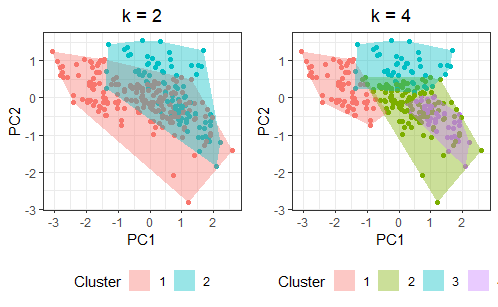

```r
princ <- prcomp(pmatrix)
nComp <- 2
project <- as.data.frame(predict(princ, newdata = pmatrix))[, 1:nComp]
project.plusk2 <- cbind(as.data.frame(project), cluster = as.factor(groupsk2),
                      Yr_InsType_Foe = enrol3$Yr_InsType_Foe)
hk2 <- do.call(rbind, lapply(unique(groupsk2),
                           function(c) {
                             f <- subset(project.plusk2, cluster == c);
                             f[chull(f),]
                           }
                           )
             )

p1 <- ggplot(project.plusk2, aes(x = PC1, y = PC2)) +
  geom_point(aes(colour = cluster), show.legend = FALSE) +
  geom_polygon(data = hk2, aes(group = cluster, fill = as.factor(cluster)),
               alpha = 0.4, linetype = 0) +
  theme_bw() +
  theme(legend.position = "bottom",
        plot.title = element_text(hjust = .5)) +
  labs(fill = "Cluster", title = "k = 2")

project.plusk4 <- cbind(as.data.frame(project), cluster = as.factor(groupsk4),
                      Yr_InsType_Foe = enrol3$Yr_InsType_Foe)
hk4 <- do.call(rbind, lapply(unique(groupsk4),
                           function(c) {
                             f <- subset(project.plusk4, cluster == c);
                             f[chull(f),]
                           }
                           )
             )

p2 <- ggplot(project.plusk4, aes(x = PC1, y = PC2)) +
  geom_point(aes(colour = cluster), show.legend = FALSE) +
  geom_polygon(data = hk4, aes(group = cluster, fill = as.factor(cluster)),
               alpha = 0.4, linetype = 0) +
  theme_bw() +
  theme(legend.position = "bottom",
        plot.title = element_text(hjust = .5)) +
  labs(fill = "Cluster", title = "k = 4")

grid.arrange(p1,p2,ncol=2)
```

```r
rm(p1,p2)
```

For $k = 2$, the clusters are not that well-separated. For $k = 4$, cluster 1 and cluster 3 are quite well-separated, while cluster 2 and cluster 4 completely overlap. However, an important question is that whether a given cluster is “real” and representing the true structures or not. To asses whether this is the case and the cluster does hold up plausible variations in the dataset, the function `clusterboot()` from `fpc` package was applied to our scaled data to evaluate the stability of a given cluster. The `clusterboot()` algorithms carries out clusterwise cluster stability assessment by resampling and then compute the *Jaccard coefficient* representing the similarities of the original clusters to the most similar clusters in the resampled data. The cluster stability is then obtained from the mean value of the Jaccard coefficient. The stability of less than 0.6 is considered as unstable. The values between 0.6 and 0.75 indicate the patterns are discovered but with low certainty. Lastly, the stability value of greater than 0.85 is considered as highly stable and possibly be the real clusters.

- Cluster stability assessment

```r
set.seed(1300)
kbest.p <- 2
cboot.hclust <- clusterboot(pmatrix, clustermethod = hclustCBI, method = "ward.D", k = kbest.p)
```

[output not shown]

[output cut: 45 more lines]

[output not shown]

```r
summary(cboot.hclust$result)
```

```
              Length Class  Mode
result          7    hclust list
noise           1    -none- logical
nc              1    -none- numeric
clusterlist     2    -none- list
partition     272    -none- numeric
clustermethod   1    -none- character
nccl            1    -none- numeric
```

```r
groups <- cboot.hclust$result$partition
```

In the code chunk above, the desired number of clusters is set to 2, and then the function `clusterboot()` was passed with hierarchical clustering method denoted by `hclustCBI`, Ward’s method denoted by `ward.D` and $k = 2$. The results of the clustering are shown above using the summary function. The vector of cluster stabilities is then obtained from the `bootmean` component of clusterboot we run above.

```r
cboot.hclust$bootmean
```

```
[1] 0.8204401 0.6843675
```

```r
1-cboot.hclust$bootbrd/100
```

```
[1] 0.83 0.73
```

The `clusterboot()` results show that both cluster 1 and 2 when $k=2$ are quite stable and the pattern is discovered with low certainty. Now, for $k=4$ we carry out the same stability assessment.

```r
set.seed(1250)
cboot.hclust2 <- clusterboot(pmatrix, clustermethod = hclustCBI, method = "ward.D", k = 4)
```

[output not shown]

[output cut: 45 more lines]

[output not shown]

```r
summary(cboot.hclust2$result)
```

```
              Length Class  Mode
result          7    hclust list
noise           1    -none- logical
nc              1    -none- numeric
clusterlist     4    -none- list
partition     272    -none- numeric
clustermethod   1    -none- character
nccl            1    -none- numeric
```

```r
groups2 <- cboot.hclust2$result$partition
```

```r
cboot.hclust2$bootmean
```

```
[1] 0.5988800 0.5992941 0.7427098 0.7876926
```

```r
1-cboot.hclust2$bootbrd/100
```

```
[1] 0.49 0.46 0.81 0.92
```

The `clusterboot()` results when $k=4$ show that both cluster 3 and 4 are quite stable. Cluster 1 and 2, on the other hand, are unstable with stability value less than 0.6.

One major drawback is that `clusterboot` assumes that we know the number of clusters beforehand, whether by looking at the cluster dendogram or simply trusting our instincts. However, intuitively guessing the number of clusters does work for some dataset but not very effective with our National Enrollment data. Luckily, we are able to effectively determine the number of clusters by using the knowledge of the total within sum of squares (WSS) and the Callinski-Harabasz index (CH).

- Total within sum of squares (WSS)

The within sum of squares is essentially the average squared distance of each point in the cluster from its centroid (mean of all the points in the cluster), while the total within sum of squares is basically the sum of the within sum of squares of all the clusters. One way to determine the number of clusters, $k$, is to calculate WSS for different values of $k$ and look for an elbow in the curve. The code chunk below create three functions which are used to calculate the total WSS value. The first function `sqr_edist` calculate a squared distance between vector $x$ and $y$. The `wss.cluster` function calculate the within sum of squares of a single cluster. Lastly, the `wss.total` function calculate the total WSS from a set of data points and cluster labels.

```r
sqr_edist <- function(x, y) {
  sum((x - y)^2)
}

wss.cluster <- function(clustermat) {
  c0 <- apply(clustermat, 2, FUN = mean)
  sum(apply(clustermat, 1, FUN = function(row){sqr_edist(row, c0)}))
}

wss.total <- function(dmatrix, labels) {
  wsstot <- 0
  k <- length(unique(labels))
  for(i in 1:k){
    wsstot <- wsstot + wss.cluster(subset(dmatrix, labels == i))
  }
  wsstot
}
```

- Calinski-Harabasz index

Firstly, we need to calculate the total sum of squares (TSS) by creating the function `totss` as in the code chunk below. Then, the function `ch_criterion` is used to calculate the CH index for a number of clusters from 1 to kmax, which in this case we choose the kmax equal to 10.

```r
totss <- function(dmatrix) {
  grandmean <- apply(dmatrix, 2, FUN=mean)
  sum(apply(dmatrix, 1,
            FUN=function(row){
              sqr_edist(row, grandmean)
              }
            )
      )
}

ch_criterion <- function(dmatrix, kmax, method = "kmeans") {
  if(!(method %in% c("kmeans", "hclust"))){
    stop("method must be one of c('kmeans', 'hclust')")
  }
  npts <- dim(dmatrix)[1] # number of rows.
  totss <- totss(dmatrix)
  wss <- numeric(kmax)
  crit <- numeric(kmax)
  wss[1] <- (npts - 1) * sum(apply(dmatrix, 2, var))
  for(k in 2:kmax) {
    if(method == "kmeans") {
      clustering <- kmeans(dmatrix, k, nstart = 10, iter.max = 100)
      wss[k] <- clustering$tot.withinss
    }else { # hclust
      d <- dist(dmatrix, method = "euclidean")
      pfit <- hclust(d, method = "ward.D")
      labels <- cutree(pfit, k = k)
      wss[k] <- wss.total(dmatrix, labels)
    }
  }
  bss <- totss - wss
  crit.num <- bss/(0:(kmax - 1))
  crit.denom <- wss/(npts - 1:kmax)
  list(crit = crit.num/crit.denom, wss = wss, totss = totss)
}
```

To efficiently calculate and compare the WSS and CH index for the National Enrollment data, we can make use of visualisation.

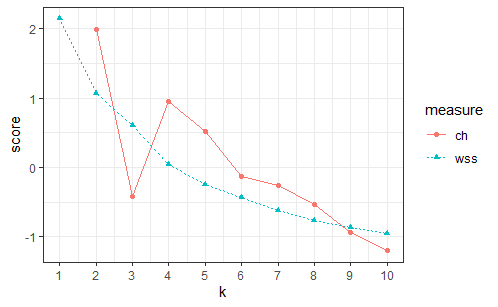

```r
clustcrit <- ch_criterion(pmatrix, 10, method = "hclust")
critframe <- data.frame(k = 1:10, ch = scale(clustcrit$crit), wss = scale(clustcrit$wss))
critframe <- melt(critframe, id.vars = c("k"), variable.name = "measure", value.name = "score")

ggplot(critframe, aes(x = k, y = score, colour = measure)) +
  geom_point(aes(shape = measure)) +
  geom_line(aes(linetype = measure)) +
  scale_x_continuous(breaks = 1:10, labels = 1:10) +
  theme_bw()
```

It is obvious that the CH criterion is maximized at $k = 2$ with another local maximum at $k = 4$. The WSS plot on the other hand is quite difficult to determine the elbow. Nevertheless, we can say that there is a slight elbow at $k = 2$ and $k = 4$ for the WSS criterion also. Hence, both indices seem to suggest that there are 2 or 4 clusters, which matches with our preliminary investigation carried out at the beginning of this section.

## 3.3 K-means Clustering

Since our data is quantitative, K-means clustering is known to be another effective way to carry out the clustering process. It is also a much quicker and simpler clustering method compare to the hierarchical clustering we did in the previous section. However, its drawback is that we must choose the number of clusters $k$ in advance. Firstly, we start by passing the function `kmeans` to our scaled data with the chosen number of $k$. Here, we chose the number of $k = 2$ with 100 random start and 100 maximum iterations per run.

Again, by passing the function `summary` to our `kmeans` output, we can see that `kmeans` essentially returns all the sum of squares measures. The `centers` component in this case is a matrix representing the centroids of the clusters.

```r
pclusters <- kmeans(pmatrix, kbest.p, nstart = 100, iter.max = 100)
summary(pclusters)
```

```
             Length Class  Mode
cluster      272    -none- numeric
centers       12    -none- numeric
totss          1    -none- numeric
withinss       2    -none- numeric
tot.withinss   1    -none- numeric
betweenss      1    -none- numeric
size           2    -none- numeric
iter           1    -none- numeric
ifault         1    -none- numeric
```

```r
pclusters$centers
```

```
      avgAge    avgATAR   propMale    noInter noHomeState noInterState
1  0.4699894  0.1069322 -0.4164467  0.7936461   1.2514795    1.1828354
2 -0.1822408 -0.0414635  0.1614793 -0.3077403  -0.4852676   -0.4586505
```

Now, let’s extract the clusters found by kmeans with $k=2$.

```r
groups <- pclusters$cluster
print_clusters(groups, kbest.p)
```

```
[1] "cluster 1"
```

|  | Yr_InsType_Foe | avgAge | avgATAR | propMale | noInter | noHomeState | noInterState |
| --- | --- | --- | --- | --- | --- | --- | --- |
| 18 | 2005 Non-Go8 University Health | 18.90090 | 79.91892 | 0.1711712 | 1 | 12 | 98 |
| 20 | 2005 Non-Go8 University Management And Commerc | 18.90435 | 76.43478 | 0.4347826 | 6 | 7 | 102 |
| 22 | 2005 Non-Go8 University Society And Culture | 19.40217 | 75.02174 | 0.3115942 | 3 | 9 | 126 |
| 34 | 2006 Go8 University Management And Commerc | 18.60241 | 89.81928 | 0.5301205 | 8 | 5 | 70 |
| 36 | 2006 Go8 University Society And Culture | 19.05200 | 87.03200 | 0.3440000 | 3 | 2 | 120 |
| 40 | 2006 Non-Go8 University Education | 20.71849 | 76.61345 | 0.2184874 | 0 | 10 | 109 |
| 42 | 2006 Non-Go8 University Health | 19.61515 | 77.22424 | 0.2000000 | 1 | 5 | 159 |
| 44 | 2006 Non-Go8 University Management And Commerc | 19.89140 | 76.78281 | 0.5294118 | 2 | 12 | 207 |
| 46 | 2006 Non-Go8 University Society And Culture | 20.18130 | 77.77099 | 0.3244275 | 1 | 13 | 248 |
| 54 | 2007 Go8 University Health | 19.06875 | 90.88750 | 0.2500000 | 5 | 9 | 66 |

[output cut: 66 more lines]

```
[1] "cluster 2"
```

|  | Yr_InsType_Foe | avgAge | avgATAR | propMale | noInter | noHomeState | noInterState |
| --- | --- | --- | --- | --- | --- | --- | --- |
| 1 | 2005 College Engineering And Relate | 17.00000 | 93.00000 | 1.00000000 | 0 | 1 | 0 |
| 2 | 2005 College Society And Culture | 18.00000 | 74.00000 | 0.00000000 | 0 | 0 | 1 |
| 3 | 2005 Go8 University Agriculture, Environme | 19.00000 | 68.37500 | 0.50000000 | 1 | 0 | 7 |
| 4 | 2005 Go8 University Architecture And Build | 18.22222 | 87.22222 | 0.44444444 | 0 | 0 | 9 |
| 5 | 2005 Go8 University Creative Arts | 18.12500 | 86.93750 | 0.31250000 | 0 | 1 | 15 |
| 6 | 2005 Go8 University Education | 18.83333 | 79.50000 | 0.66666667 | 0 | 1 | 5 |
| 7 | 2005 Go8 University Engineering And Relate | 17.61538 | 91.50000 | 0.84615385 | 1 | 4 | 21 |
| 8 | 2005 Go8 University Health | 18.28571 | 95.07143 | 0.28571429 | 0 | 3 | 11 |
| 9 | 2005 Go8 University Information Technology | 18.60000 | 88.80000 | 0.60000000 | 0 | 1 | 4 |
| 10 | 2005 Go8 University Management And Commerc | 18.02564 | 88.61538 | 0.51282051 | 2 | 7 | 30 |

[output cut: 186 more lines]

Interestingly, `hclust` and `kmeans` do not return the same clustering for $k=2$. With about the same average age, average ATAR and proportion of male in both clusters, the number of international enrollments, the number of homestate enrollments and the number of interstate enrollment of cluster 1 seems to be substantially higher than cluster 2.

As an alternative of ggplot, we can also visualise clusters found by k-means clustering with the function `cusplot` from the package `cluster` as shown below. The following code chunk was adapted from Manuel Ramon’s answer to the question “[How to produce a pretty plot of the results of k-means cluster analysis?](https://stats.stackexchange.com/questions/31083/how-to-produce-a-pretty-plot-of-the-results-of-k-means-cluster-analysis)” on stackexchange.com.

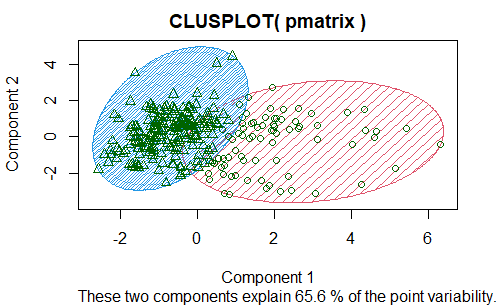

```r
clusplot(pmatrix, pclusters$cluster, color = TRUE, shade = TRUE, labels = 1, lines = 0)
```

Rather than guessing what the number of clusters or $k$ is, there is a much faster and more convenient way of determining the best possible value for $k$. By using the function `kmeansruns` available in the `fpc` package, we are able to pick the best $k$ based on the Calinski-Harabasz index (ch) or the average silhouette width (asw).

```r
clustering.ch <- kmeansruns(pmatrix, krange = 1:10, criterion = "ch")
clustering.ch$bestk
```

```
[1] 2
```

```r
clustering.asw <- kmeansruns(pmatrix, krange = 1:10, criterion = "asw")
clustering.asw$bestk
```

```
[1] 2
```

Running `kmeansruns` for $k$ range from 1 to 10 have given us the best $k$ value of 2 for both criterion. Alternatively, we can plot the values for the two criteria across the krange of 1 to 10 to have a better understanding.

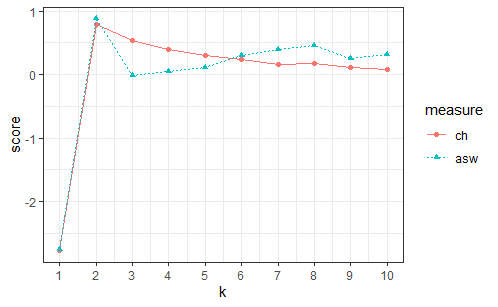

```r
critframe <- data.frame(k = 1:10, ch = scale(clustering.ch$crit),
                        asw = scale(clustering.asw$crit))
critframe <- melt(critframe, id.vars = c("k"), variable.name = "measure", value.name = "score")
ggplot(critframe, aes(x = k, y = score, colour = measure)) +
  geom_point(aes(shape = measure)) +
  geom_line(aes(linetype = measure)) +
  scale_x_continuous(breaks = 1:10, labels = 1:10) +
  theme_bw()
```

Obviously, the elbow of both criterion is at $k=2$. From the plot, another possible number of clusters could be $k=8$.

Now, let’s carry out the stability assessment one more time for k-means clustering. Again, with the function `clusterboot` with `kmeansCBI` method, we can extract the stability numbers from `bootmean` component and the number of times the clusters were dissolved from `bootbrd` component.

```r
kbest.p <- 2
cboot <- clusterboot(pmatrix, clustermethod = kmeansCBI, runs = 100,
                     iter.max = 100, krange = kbest.p, seed = 15555)
```

[output not shown]

[output cut: 45 more lines]

[output not shown]

```r
cboot$bootmean
```

```
[1] 0.9220978 0.9709648
```

```r
1-cboot$bootbrd/100
```

```
[1] 1 1
```

The stability number for both cluster 1 and 2 are very high in this case (greater than 0.85), which indicates high stability in both clusters. Hence, these two clusters we found using the k-means clustering method are very likely to be the real clusters. Comparing with the results we obtained from Hierarchical clustering method, clusters based on k-means clustering have a considerably higher stability values. Hence, K-means clustering performs better in finding enrolment patterns in the National Enrollment data.

# 4 References

Zumel, N.,& Mount, J.(2014). *Practical Data Science with R*. Shelther Island, NY: Manning Publications Co.

Receiver operating characteristic. (n.d.). Retrieved October 3, 2019, from https://en.wikipedia.org/wiki/Receiver_operating_characteristic